# Call campaign data analysis

Pau Bestard

jan 2024

# 1 About

This is a project made with the objective of familiarizing with data analysis and profile/cluster creation utilizing various R packages and techniques.

We will use a dataset related to an internal telemarketing campaign of a Portuguese bank. Link to the dataset: https://archive.ics.uci.edu/dataset/222/bank+marketing

From this dataset, the obvious value lies in creating profiles of potential subscribers. Therefore, the analysis of the data will focus on variables related to the client, clustering of the data, and the effect of this on the conversion ratio.

We will start by importing the file and visualizing the general data structure:

```r
data <- read.csv("./bank-full.csv", sep=";")
summary(data)
```

```
##       age            job              marital           education
##  Min.   :18.00   Length:45211       Length:45211       Length:45211
##  1st Qu.:33.00   Class :character   Class :character   Class :character
##  Median :39.00   Mode  :character   Mode  :character   Mode  :character
##  Mean   :40.94
##  3rd Qu.:48.00
##  Max.   :95.00
##    default             balance         housing              loan
##  Length:45211       Min.   : -8019   Length:45211       Length:45211
##  Class :character   1st Qu.:    72   Class :character   Class :character
##  Mode  :character   Median :   448   Mode  :character   Mode  :character
##                     Mean   :  1362
##                     3rd Qu.:  1428
##                     Max.   :102127
##    contact               day           month              duration
##  Length:45211       Min.   : 1.00   Length:45211       Min.   :   0.0
##  Class :character   1st Qu.: 8.00   Class :character   1st Qu.: 103.0
##  Mode  :character   Median :16.00   Mode  :character   Median : 180.0
##                     Mean   :15.81                      Mean   : 258.2
##                     3rd Qu.:21.00                      3rd Qu.: 319.0
##                     Max.   :31.00                      Max.   :4918.0
##     campaign          pdays          previous          poutcome
##  Min.   : 1.000   Min.   : -1.0   Min.   :  0.0000   Length:45211
##  1st Qu.: 1.000   1st Qu.: -1.0   1st Qu.:  0.0000   Class :character
##  Median : 2.000   Median : -1.0   Median :  0.0000   Mode  :character
##  Mean   : 2.764   Mean   : 40.2   Mean   :  0.5803
##  3rd Qu.: 3.000   3rd Qu.: -1.0   3rd Qu.:  0.0000
##  Max.   :63.000   Max.   :871.0   Max.   :275.0000
##       y
##  Length:45211
##  Class :character
##  Mode  :character
##
##
##
```

# 2 Data summary

## 2.1 Customer Data

1. age: Age of the individual,
   - Integer range 18 - 95
2. job: Type of job of the individual,
   - Categorical string:
     - “admin.”, “unknown”, “unemployed”, “management”, “housemaid”, “entrepreneur”, “student”, “blue-collar”, “self-employed”, “retired”, “technician”, “services”
3. marital: Marital status,
   - Categorical string:
     - “married”, “divorced”, “single”
4. education: Level of education,
   - Categorical string:
     - “unknown”, “secondary”, “primary”, “tertiary”
5. default: Defines if they have credit in the bank,
   - Binary:
     - “yes”, “no”
6. balance: Average annual income in Euros,
   - Integer range -8019 - 102127
7. housing: Defines if they have a housing loan,
   - Binary:
     - “yes”, “no”
8. loan: Defines if they have a personal loan,
   - Binary:
     - “yes”, “no”

## 2.2 Data from the last contact of this advertising campaign

9. contact: Contact method,
   - Categorical string:
     - “unknown”, “telephone”, “cellular”
10. day: Day of the month of last contact,
    - Integer range 1 - 31
11. month: Month of the last contact,
    - Categorical string:
      - “jan”, “feb”, “mar”, …, “nov”, “dec”
12. duration: Duration of the last contact in seconds,
    - Integer range 0 - 4918

## 2.3 Other data

13. campaign: Number of contacts made during this campaign with this customer including last contact,
    - Integer range 1 - 63
14. pdays: Number of days elapsed since the last contact, -1 represents this is the first contact,
    - Integer range -1 - 871
15. previous: Number of contacts made prior to this campaign,
    - Integer range 0 - 275
16. poutcome: Outcome of the previous marketing campaign,
    - Categorical string:
      - “unknown”, “other”, “failure”, “success”

Campaign Outcome

17. y: Defines if the customer has subscribed,
    - Binary:
      - “yes”, “no”

## 2.4 Visualizing category percentages

We will create categories for age and balance to aid in visualization:

```r
data$age_group <- cut(data$age, breaks = seq(0, 100, by = 10), include.lowest = FALSE)

data$balance_group <- cut(data$balance, breaks = c(-Inf, 0,2000,5000,10000, 20000, 30000,40000,50000, Inf), labels = c("Negative","0-2k","2k-5k","5-10k", "10-20k", "20-30k","30-40k", "40-50k", "50k+"), include.lowest = TRUE)

data$month_digit <- match(data$month, c("jan", "feb", "mar", "apr", "may", "jun", "jul", "aug", "sep", "oct", "nov", "dec"))
```

Bar plots showcasing the percentage of values are used to better understand the data population:

```r
library(ggplot2)

create_percentage_bar_plot <- function(data, column) {
  percentage <- prop.table(table(data[[column]])) * 100

  df <- data.frame(Category = names(percentage), Percentage = as.numeric(percentage))

  if (column == "month") {
    month_order <- factor(df$Category, levels = c("jan", "feb", "mar", "apr", "may", "jun", "jul", "aug", "sep", "oct", "nov", "dec"))

    ggplot(df, aes(x = month_order, y = Percentage, fill = Category)) +
      geom_bar(stat = "identity") +
      labs(title = paste("Percentage of", column),
           x = column,
           y = "Percentage") +
      theme_minimal() +
      theme(axis.text.x = element_text(angle = 45, hjust = 1))
  } else {
    ggplot(df, aes(x = Category, y = Percentage, fill = Category)) +
      geom_bar(stat = "identity") +
      labs(title = paste("Percentage of", column),
           x = column,
           y = "Percentage") +
      theme_minimal() +
      theme(axis.text.x = element_text(angle = 45, hjust = 1))
  }
}

columns <- c("job", "education", "month", "marital", "age_group", "balance_group")
plots <- lapply(columns, function(col) create_percentage_bar_plot(data, col))
```

### 2.4.1 Job percentages

We observe “blue-collar”, “management” and “technician” as the highest populations

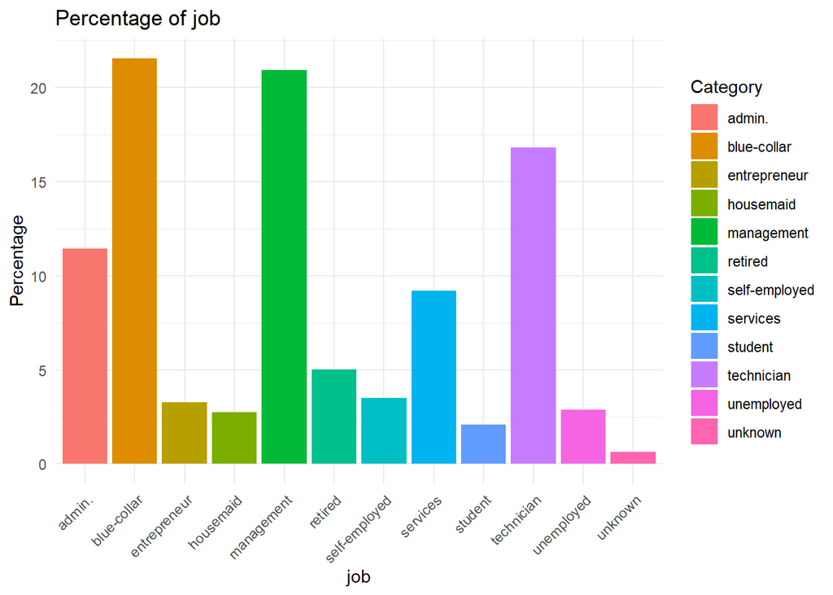

```r
print(plots[[1]])
```

### 2.4.2 Education percentages

We observe “secondary” and “tertiary” as the highest populations

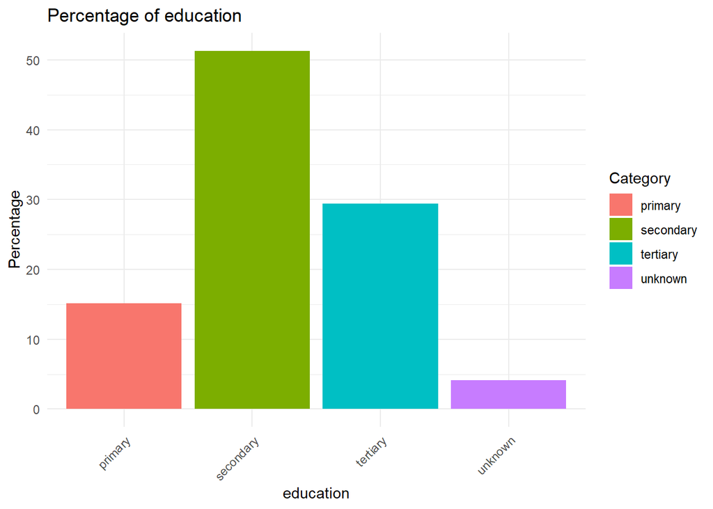

```r
print(plots[[2]])
```

### 2.4.3 Month of call percentages

Although not used in this project we can see the highest activity month is “may”

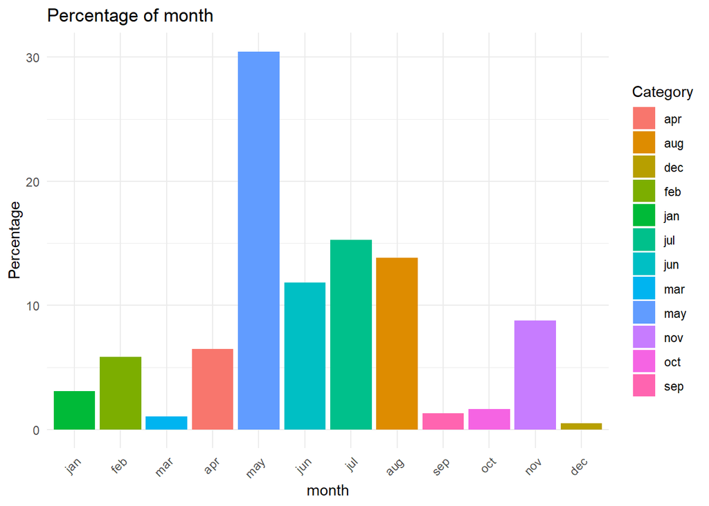

```r
print(plots[[3]])
```

### 2.4.4 Marital status percentages

We observe “married” as the highest population

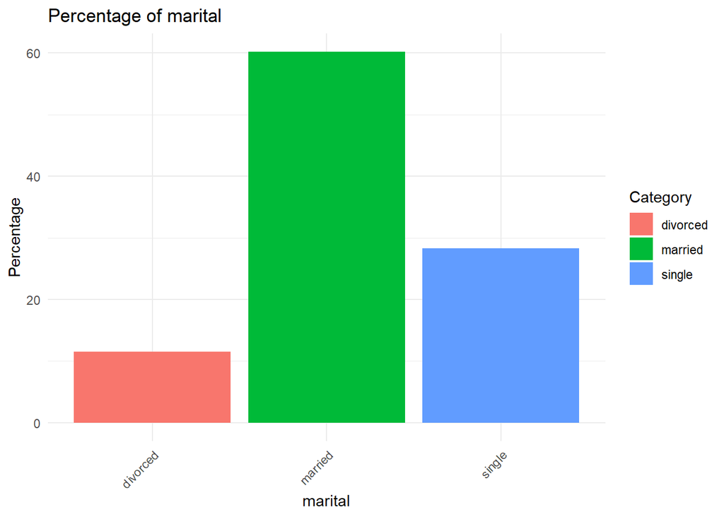

```r
print(plots[[4]])
```

### 2.4.5 Age group percentages

We observe the 30-40 to be the highest population group and notably a vast mayority of the populations is in the bracket 20-60

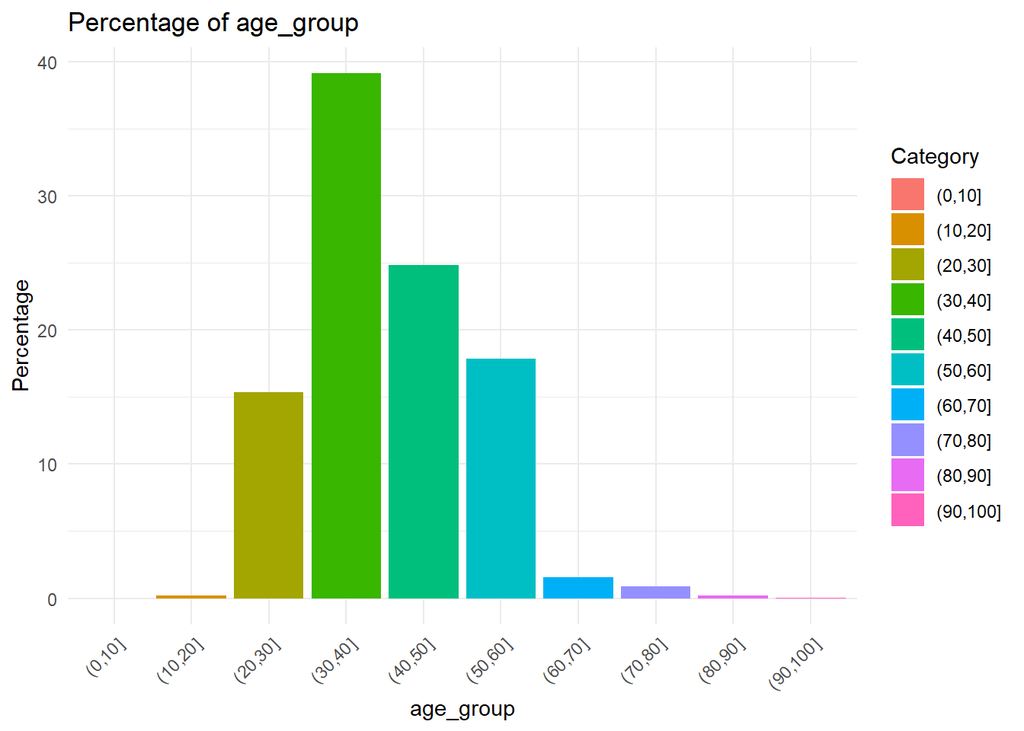

```r
print(plots[[5]])
```

### 2.4.6 Balance group percentages

We observe the mayority of the population is in the range 0-2k, notably there is a very high percentage of the population in the “red”

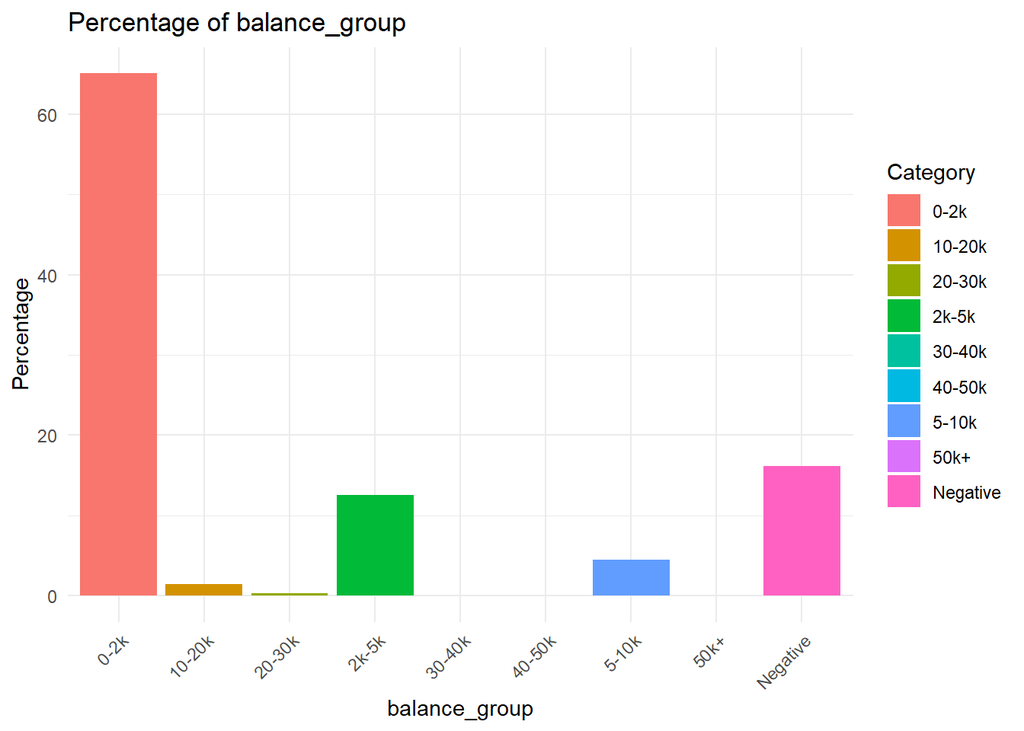

```r
print(plots[[6]])
```

# 3 Unsupervised models

To begin we will use unsupervised models to try and create clusters from the data, for this we will use only columns 1:8(personal information).

## 3.1 Kmeans

The first approach will be utilizing kmeans, for this we will convert all data to numeric and scaling it.

```r
datakmeans <- na.omit(data[1:8])
datakmeans$job <- as.numeric(factor(datakmeans$job, levels = c("admin.", "unknown", "unemployed", "management", "housemaid", "entrepreneur", "student", "blue-collar", "self-employed", "retired", "technician", "services")))
datakmeans$marital <- as.numeric(factor(datakmeans$marital, levels = c("married", "divorced", "single")))
datakmeans$education <- as.numeric(factor(datakmeans$education, levels = c("unknown", "secondary", "primary", "tertiary")))
datakmeans$default <- as.numeric(factor(datakmeans$default, levels = c("yes", "no")))
datakmeans$housing <- as.numeric(factor(datakmeans$housing, levels = c("yes", "no")))
datakmeans$loan <- as.numeric(factor(datakmeans$loan, levels = c("yes", "no")))

scaled_data <- scale(datakmeans)
```

To find the optimal number of clusters we will create an elbow method, showing the increase in “quality” between the amount of nodes. Take notice of the use of “set.seed” as kmeans creates centroids “randomly” and results could vary with multiple executions of the code.

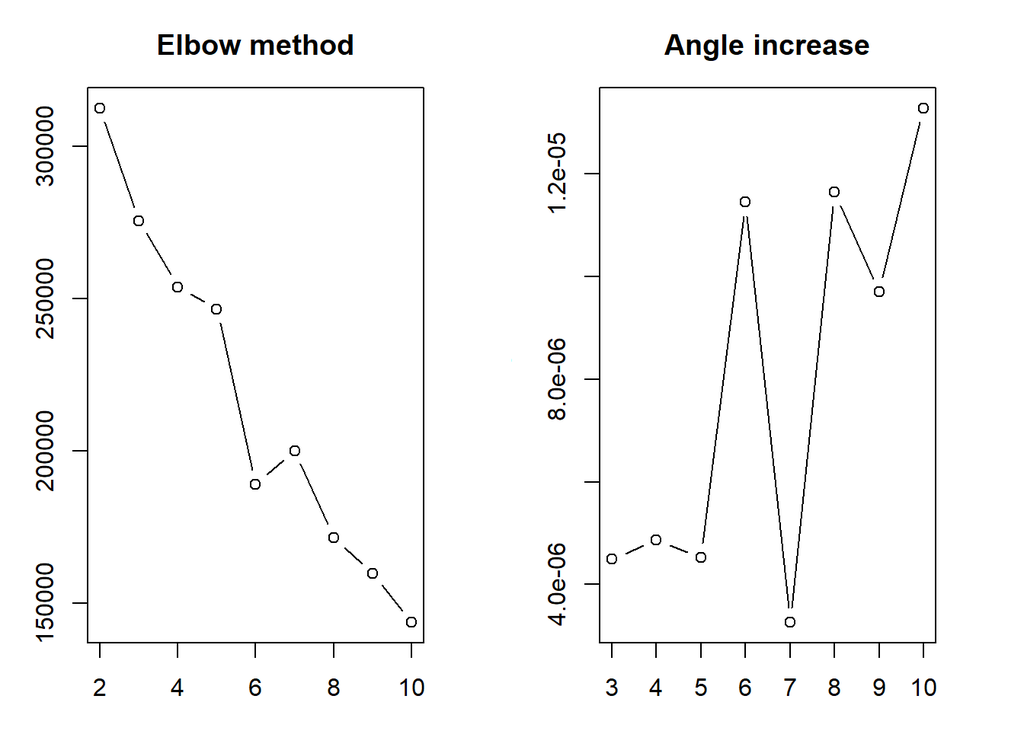

```r
set.seed(123)
k_values <- 2:10
inertia <- sapply(k_values, function(k) kmeans(scaled_data, centers = k)$tot.withinss)
angles <- numeric(length(k_values))
calculate_angle <- function(x1, y1, x2, y2) {
  dot_product <- x1 * x2 + y1 * y2
  magnitude_product <- sqrt(x1^2 + y1^2) * sqrt(x2^2 + y2^2)
  angle <- acos(dot_product / magnitude_product)
  return(angle)
}
for (i in 2:length(k_values)) {
  angles[i] <- calculate_angle(k_values[i-1], inertia[i-1], k_values[i], inertia[i])
}
par(mfrow = c(1, 2), mar = c(3, 3, 3, 3))
plot(k_values, inertia, type = "b",   xlab = "Number of clusters",
     ylab = "Inertia", main = "Elbow method")
plot(k_values[-1], angles[-1], type = "b",   xlab = "Number of clusters",
     ylab = "Angle", main = "Angle increase")
```

We will utilize k = 6 for the amount of centroids, we will now create and observe the clusters

```r
library(dplyr)
```

```r
library(ggplot2)
set.seed(123)
kmeans_result <- kmeans(scaled_data, centers = 6)
data$cluster <- as.factor(kmeans_result$cluster)

overall_summary <- data %>%
  summarise(
            size = n(),
            avg_age = round(mean(age), 2),
            avg_balance = round(mean(balance), 2),
            most_common_job = names(sort(table(job), decreasing = TRUE))[1],
            job_frequency_percent = round(max(table(job)) / sum(table(job)) * 100, 2),
            positive_outcome_percent = round(sum(y == "yes") / n() * 100, 2))


cluster_summary_kmeans <- data %>%
  group_by(cluster) %>%
  summarise(size = n(),
            avg_age = round(mean(age),2),
            avg_balance = round(mean(balance),2),
            most_common_job = names(sort(table(job), decreasing = TRUE))[1],
            job_frequency_percent = round(max(table(job))/ sum(table(job)) * 100, 2) ,
            positive_outcome_percent = round(sum(y == "yes") / n() * 100, 2)
            )
cluster_summary_kmeans <- bind_rows(overall_summary,cluster_summary_kmeans)

print(cluster_summary_kmeans)
```

```
##    size avg_age avg_balance most_common_job job_frequency_percent
## 1 45211   40.94     1362.27     blue-collar                 21.53
## 2 11576   48.19     1908.49      management                 23.97
## 3  6125   33.71     1232.66     blue-collar                 21.67
## 4  5501   33.26     1464.55      management                 26.56
## 5  5323   41.14     1520.59      management                 49.13
## 6  7238   40.55      754.44     blue-collar                 23.27
## 7  9448   41.38     1093.96     blue-collar                 48.21
##   positive_outcome_percent cluster
## 1                    11.70    <NA>
## 2                    16.46       1
## 3                    10.04       2
## 4                    21.89       3
## 5                     8.36       4
## 6                     6.67       5
## 7                     6.74       6
```

### 3.1.1 Cluster observation

To better understand the clusters generated, we will observe them in different plots, looking for vertices with high density of a single cluster, defining that value as characteristic for the “profile” that represents the cluster.

```r
require(gridExtra)
```

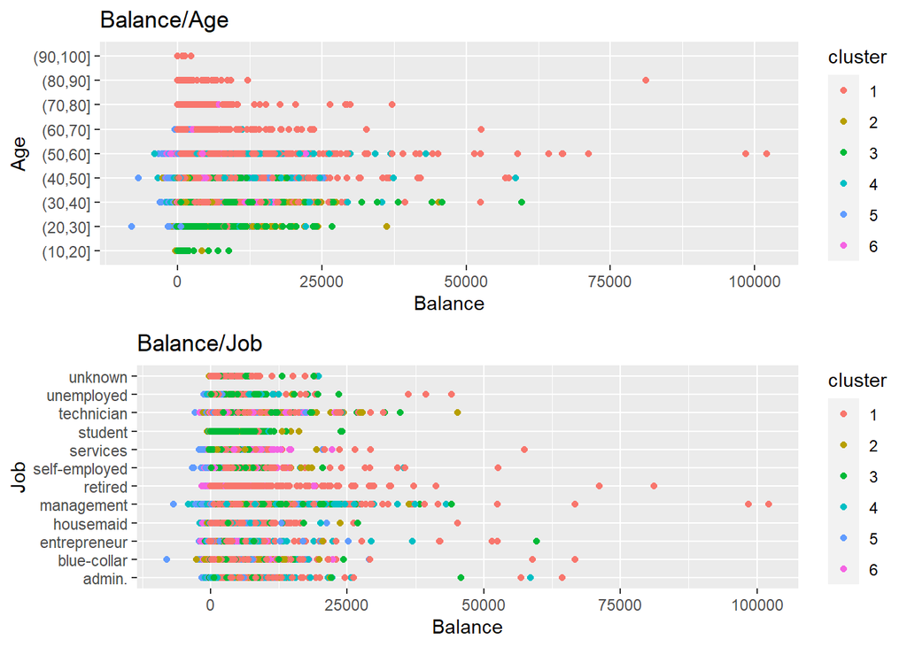

```r
plot1 <- ggplot(data, aes(x = balance, y = age_group, color = cluster)) +
  geom_point() +
  labs(title = "Balance/Age",
       x = "Balance",
       y = "Age")
plot2 <- ggplot(data, aes(x = balance, y = job, color = cluster)) +
  geom_point() +
  labs(title = "Balance/Job",
       x = "Balance",
       y = "Job")

grid.arrange(plot1, plot2, ncol=1)
```

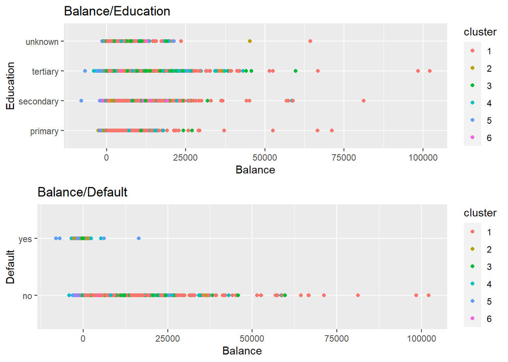

```r
plot1 <- ggplot(data, aes(x = balance, y = education, color = cluster)) +
  geom_point() +
  labs(title = "Balance/Education",
       x = "Balance",
       y = "Education")

plot2 <- ggplot(data, aes(x = balance, y = default, color = cluster)) +
  geom_point() +
  labs(title = "Balance/Default",
       x = "Balance",
       y = "Default")

grid.arrange(plot1, plot2, ncol=1)
```

We comment on some evident aspects:

- Cluster 1 seems to “capture” the profile of retired individuals, with the majority being of advanced age and retired within this cluster.
- Cluster 3 seems to “capture” the profile of students, with the majority being of young age and students within this cluster.

### 3.1.2 Conclusions

One of the key indicators of whether the clustering is creating profiles useful for our goal is that the created clusters average percentage of outcomes is as different as possible from the global average, meaning the traits of the clusters can be used to potentially predict the result for future campaigns.

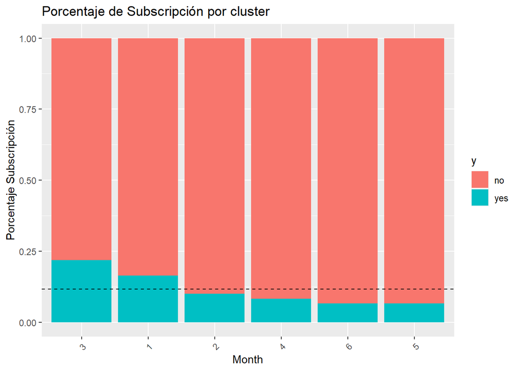

```r
cluster_percentage_yes <- aggregate(y ~ cluster, data = data, FUN = function(x) sum(x == "yes") / length(x))
sorted_clusters <- cluster_percentage_yes[order(cluster_percentage_yes$y, decreasing = TRUE), ]
data$cluster <- factor(data$cluster, levels = sorted_clusters$cluster)


total_percentage_yes <- (sum(data$y == "yes") / nrow(data))

plot1 <- ggplot(data, aes(x = cluster, fill = y)) +
  geom_bar(position = "fill") +
  labs(title = "Porcentaje de Subscripción por cluster",
       x = "Month",
       y = "Porcentaje Subscripción") +
  geom_hline(yintercept = total_percentage_yes, linetype = "dashed", color = "black") +
  theme(axis.text.x = element_text(angle = 45, hjust = 1))


grid.arrange(plot1, ncol = 1)
```

The generated clusters appear to be particularly useful, indicating a significant difference in the subscription ratio to groups 1 and 3, which had already been observed as outliers in the representation. These data could be interpreted, therefore, as profiles of potential customers to focus on in future campaigns.

## 3.2 Kmeans, Manhattan distance

The previous unsupervised model will be generated again, but using a different distance metric in order to observe diferences.

We will now apply the “Manhattan distance” to the dataset, in this case we are limiting the sample size due to the processing speed limitations of the device used to compile.

```r
library(flexclust)
library(proxy)
set.seed(123)
dataTree <- na.omit(data[, c(1:8)])

indexes = sample(1:nrow(data), size=5000)
manhattanData <- scaled_data[indexes,]

dist_manhattan <- proxy::dist(as.matrix(manhattanData), method = "Manhattan")

kmeans_result_manhattan <- kcca(dist_manhattan, k = 6, family = kccaFamily("kmeans"))

data$cluster_manhattan <- as.factor(kmeans_result$cluster)
```

We will observe the generated clusters.

```r
cluster_manhattan <- data %>%
  group_by(cluster_manhattan) %>%
  summarise(size = n(),
            avg_age = round(mean(age),2),
            avg_balance = round(mean(balance),2),
            most_common_job = names(sort(table(job), decreasing = TRUE))[1],
            job_frequency_percent = round(max(table(job))/ sum(table(job)) * 100, 2) ,
            positive_outcome_percent = round(sum(y == "yes") / n() * 100, 2)
  )
cluster_manhattan <- bind_rows(overall_summary,cluster_manhattan)

print(cluster_manhattan)
```

```
##    size avg_age avg_balance most_common_job job_frequency_percent
## 1 45211   40.94     1362.27     blue-collar                 21.53
## 2 11576   48.19     1908.49      management                 23.97
## 3  6125   33.71     1232.66     blue-collar                 21.67
## 4  5501   33.26     1464.55      management                 26.56
## 5  5323   41.14     1520.59      management                 49.13
## 6  7238   40.55      754.44     blue-collar                 23.27
## 7  9448   41.38     1093.96     blue-collar                 48.21
##   positive_outcome_percent cluster_manhattan
## 1                    11.70              <NA>
## 2                    16.46                 1
## 3                    10.04                 2
## 4                    21.89                 3
## 5                     8.36                 4
## 6                     6.67                 5
## 7                     6.74                 6
```

### 3.2.1 Cluster observation

Let’s visualize the clusters.

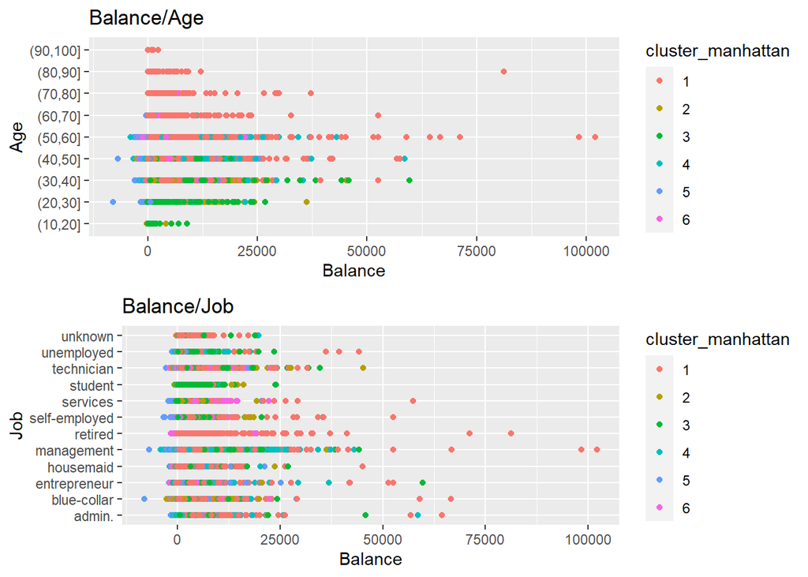

```r
require(gridExtra)


plot1 <- ggplot(data, aes(x = balance, y = age_group, color = cluster_manhattan)) +
  geom_point() +
  labs(title = "Balance/Age",
       x = "Balance",
       y = "Age")
plot2 <- ggplot(data, aes(x = balance, y = job, color = cluster_manhattan)) +
  geom_point() +
  labs(title = "Balance/Job",
       x = "Balance",
       y = "Job")

grid.arrange(plot1, plot2, ncol=1)
```

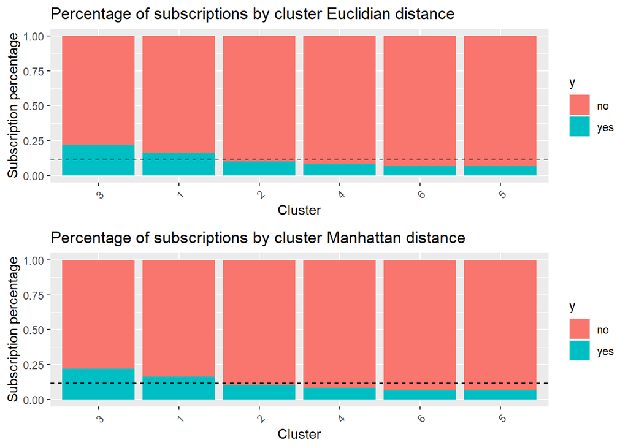

```r
cluster_percentage_yes <- aggregate(y ~ cluster_manhattan, data = data, FUN = function(x) sum(x == "yes") / length(x))
sorted_clusters <- cluster_percentage_yes[order(cluster_percentage_yes$y, decreasing = TRUE), ]
data$cluster_manhattan <- factor(data$cluster_manhattan, levels = sorted_clusters$cluster)


total_percentage_yes <- (sum(data$y == "yes") / nrow(data))

plot1 <- ggplot(data, aes(x = cluster, fill = y)) +
  geom_bar(position = "fill") +
  labs(title = "Percentage of subscriptions by cluster Euclidian distance",
       x = "Cluster",
       y = "Subscription percentage") +
  geom_hline(yintercept = total_percentage_yes, linetype = "dashed", color = "black") +
  theme(axis.text.x = element_text(angle = 45, hjust = 1))

plot2 <- ggplot(data, aes(x = cluster_manhattan, fill = y)) +
  geom_bar(position = "fill") +
  labs(title = "Percentage of subscriptions by cluster Manhattan distance",
       x = "Cluster",
       y = "Subscription percentage") +
  geom_hline(yintercept = total_percentage_yes, linetype = "dashed", color = "black") +
  theme(axis.text.x = element_text(angle = 45, hjust = 1))


grid.arrange(plot1,plot2, ncol = 1)
```

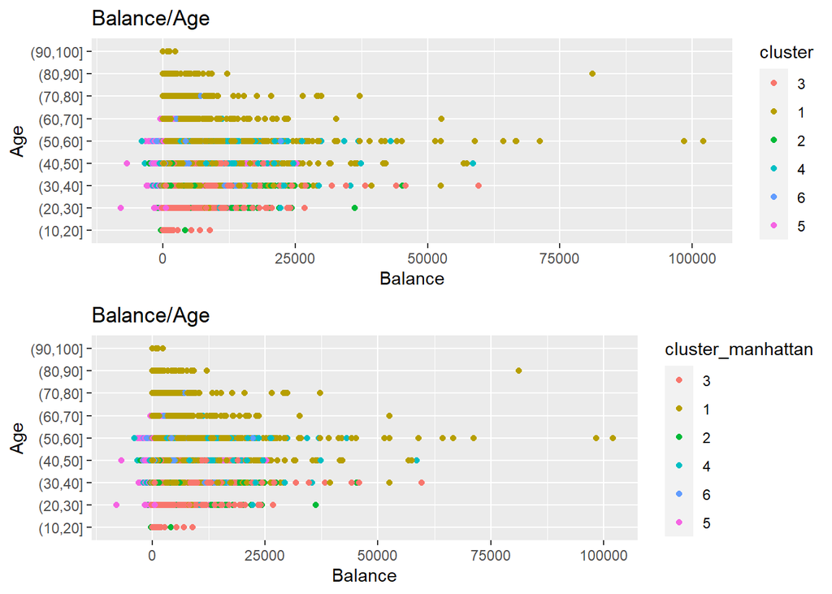

```r
require(gridExtra)


plot1 <- ggplot(data, aes(x = balance, y = age_group, color = cluster)) +
  geom_point() +
  labs(title = "Balance/Age",
       x = "Balance",
       y = "Age")
plot2 <- ggplot(data, aes(x = balance, y = age_group, color = cluster_manhattan)) +
  geom_point() +
  labs(title = "Balance/Age",
       x = "Balance",
       y = "Age")

grid.arrange(plot1, plot2, ncol=1)
```

## 3.3 DBSCAN & OPTICS

Now we will utilize the DBSCAN optics methods to create clusters. To start we will utilize the config minPts = 100 and eps_cl = 5.

```r
library(dbscan)
```

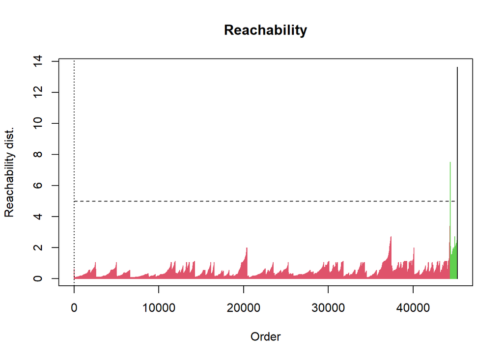

```r
library(dplyr)

optics_result <- dbscan::optics(scaled_data, minPts = 100)

dbscan_result <- extractDBSCAN(optics_result, eps_cl = 5)
data$cluster_dbscan <- as.factor(dbscan_result$cluster)

plot(dbscan_result, main="Reachability")
```

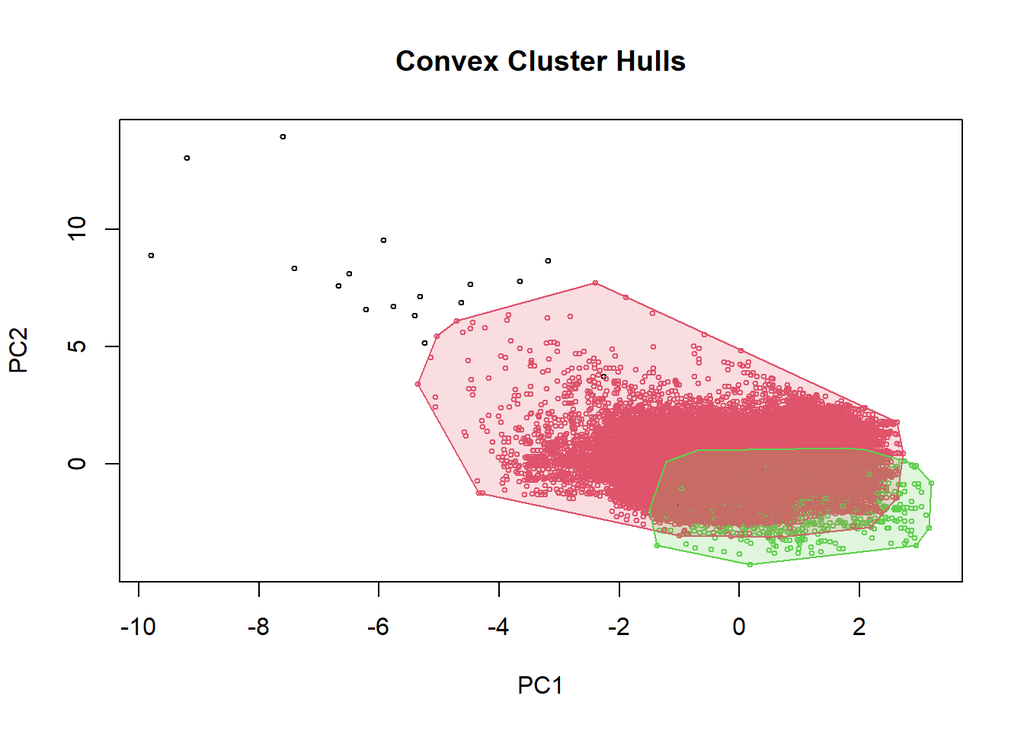

```r
hullplot(scaled_data, dbscan_result)
```

The generated clusters.

```r
cluster_summary_dbscan <- data %>%
  group_by(cluster_dbscan) %>%
  summarise(size = n(),
            avg_age = round(mean(age), 2),
            avg_balance = round(mean(balance), 2),
            most_common_job = names(sort(table(job), decreasing = TRUE))[1],
            job_frequency_percent = round(max(table(job)) / sum(table(job)) * 100, 2),
            positive_outcome_percent = round(sum(y == "yes") / n() * 100, 2)
  )
cluster_summary_dbscan <- bind_rows(overall_summary,cluster_summary_dbscan)

print(cluster_summary_dbscan)
```

```
##    size avg_age avg_balance most_common_job job_frequency_percent
## 1 45211   40.94     1362.27     blue-collar                 21.53
## 2    20   54.45    62331.05      management                 20.00
## 3 44377   40.96     1362.68     blue-collar                 21.47
## 4   814   39.53     -158.05     blue-collar                 24.69
##   positive_outcome_percent cluster_dbscan
## 1                    11.70           <NA>
## 2                    25.00              0
## 3                    11.79              1
## 4                     6.39              2
```

### 3.3.1 Testing different `eps` & `minPts`.

We will create clusters using different parameters for both eps and minPts to try and achieve better results.

We will start by changing eps to 2:

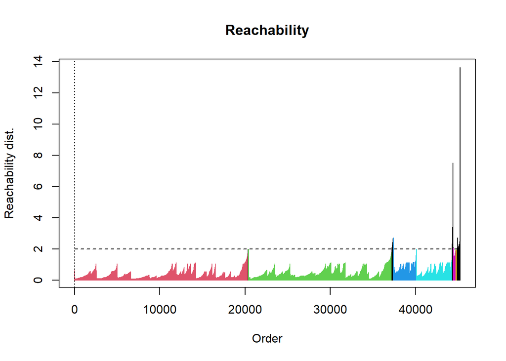

```r
dbscan_result_eps2 <- extractDBSCAN(optics_result, eps_cl = 2)
data$cluster_dbscan_eps2 <- as.factor(dbscan_result_eps2$cluster)

plot(dbscan_result_eps2, main="Reachability")
```

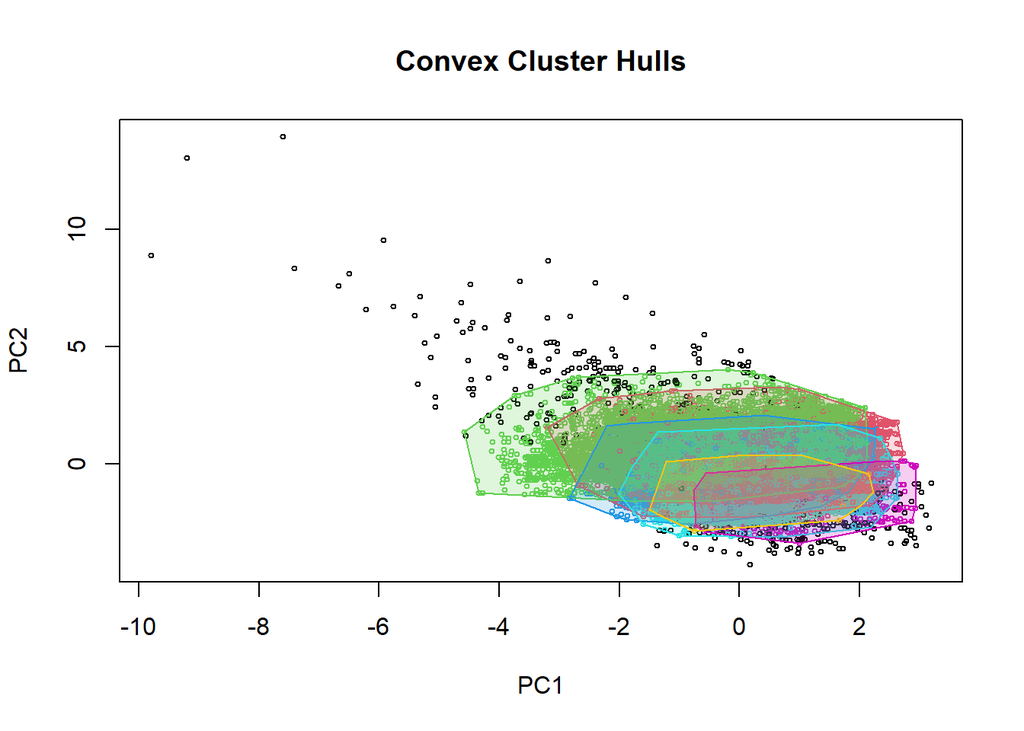

```r
hullplot(scaled_data, dbscan_result_eps2)
```

```r
cluster_summary_dbscan_eps2 <- data %>%
  group_by(cluster_dbscan_eps2) %>%
  summarise(size = n(),
            avg_age = round(mean(age), 2),
            avg_balance = round(mean(balance), 2),
            most_common_job = names(sort(table(job), decreasing = TRUE))[1],
            job_frequency_percent = round(max(table(job)) / sum(table(job)) * 100, 2),
            positive_outcome_percent = round(sum(y == "yes") / n() * 100, 2)
  )
cluster_summary_dbscan_eps2 <- bind_rows(overall_summary,cluster_summary_dbscan_eps2)

print(cluster_summary_dbscan_eps2)
```

```
##    size avg_age avg_balance most_common_job job_frequency_percent
## 1 45211   40.94     1362.27     blue-collar                 21.53
## 2   634   42.23    10799.91      management                 26.66
## 3 20377   39.15     1182.35     blue-collar                 28.56
## 4 16854   43.25     1523.13      management                 24.55
## 5  2696   42.46      715.45     blue-collar                 19.25
## 6  4213   39.38      738.27     blue-collar                 25.78
## 7   298   37.84     -198.60     blue-collar                 30.54
## 8   139   41.42       -7.26     blue-collar                 22.30
##   positive_outcome_percent cluster_dbscan_eps2
## 1                    11.70                <NA>
## 2                     9.31                   0
## 3                     8.05                   1
## 4                    18.35                   2
## 5                     7.75                   3
## 6                     6.12                   4
## 7                     6.71                   5
## 8                     7.19                   6
```

We observe a notable increase in the number of clusters with eps = 2. It is worth mentioning that only one cluster has a better ratio of the desired outcome. However, the clusters appear to be more desirable than with eps = 5, with a clearer definition of the outcome.

We will now try to further reduce eps to 1, aiming to separate the two large clusters (20k, 16k) to obtain more radical results.

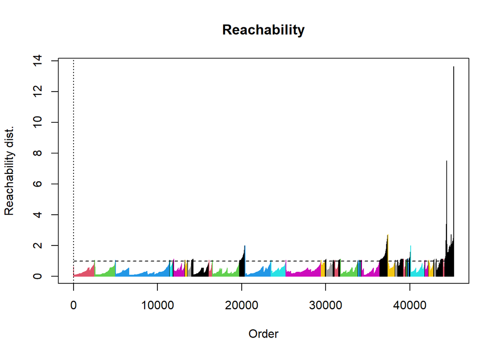

```r
dbscan_result_eps1 <- extractDBSCAN(optics_result, eps_cl = 1)
data$cluster_dbscan_eps1 <- as.factor(dbscan_result_eps1$cluster)

plot(dbscan_result_eps1, main="Reachability")
```

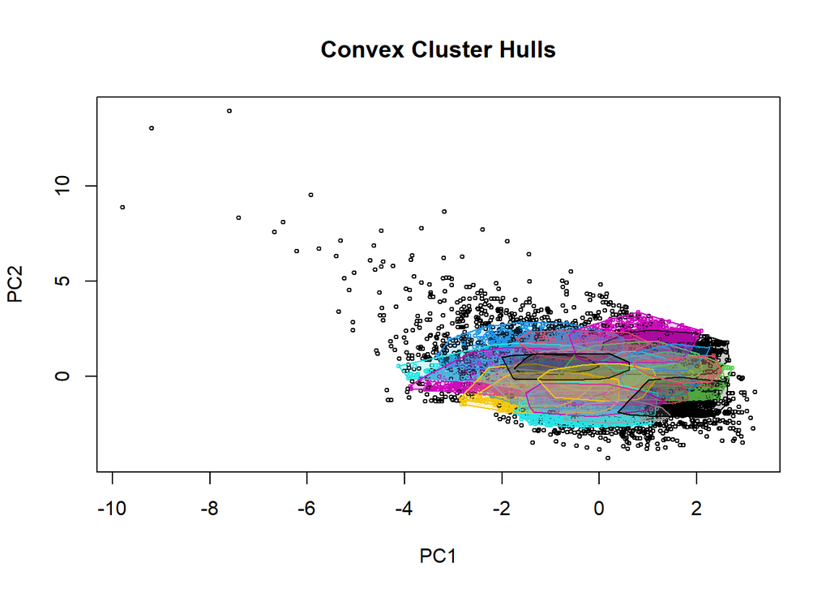

```r
hullplot(scaled_data, dbscan_result_eps1)
```

```r
cluster_summary_dbscan_eps1 <- data %>%
  group_by(cluster_dbscan_eps1) %>%
  summarise(size = n(),
            avg_age = round(mean(age), 2),
            avg_balance = round(mean(balance), 2),
            most_common_job = names(sort(table(job), decreasing = TRUE))[1],
            job_frequency_percent = round(max(table(job)) / sum(table(job)) * 100, 2),
            positive_outcome_percent = round(sum(y == "yes") / n() * 100, 2)
  )
cluster_summary_dbscan_eps1 <- bind_rows(overall_summary,cluster_summary_dbscan_eps1)

print(cluster_summary_dbscan_eps1)
```

```
##     size avg_age avg_balance most_common_job job_frequency_percent
## 1  45211   40.94     1362.27     blue-collar                 21.53
## 2   4894   44.60     4440.88      management                 18.21
## 3   2525   40.00     1143.78      management                 64.24
## 4   2457   42.81      933.28     blue-collar                 69.80
## 5   6436   40.05      973.99     blue-collar                 34.03
## 6    392   44.74      641.84     blue-collar                 45.92
## 7   1331   42.12      687.85          admin.                 24.72
## 8    275   46.15      698.92     blue-collar                 64.36
## 9    448   43.35      897.19      management                 79.91
## 10  1911   33.77     1203.77      management                 54.95
## 11   399   35.62      703.73     blue-collar                 81.20
## 12  3220   33.36      840.70     blue-collar                 23.66
## 13  3099   43.82     1396.55      management                 60.79
## 14  1763   52.05     1206.02     blue-collar                 38.06
```

[output cut: 57 more lines]

We see that the clusters of significant size have been separated; however, it would be necessary to interpret correctly the larger population, especially the high number of small clusters.

We will now check the effect of modifying the minimum number of points for each center, minPts = 50, with eps = 5 to try to create more specific centroids.

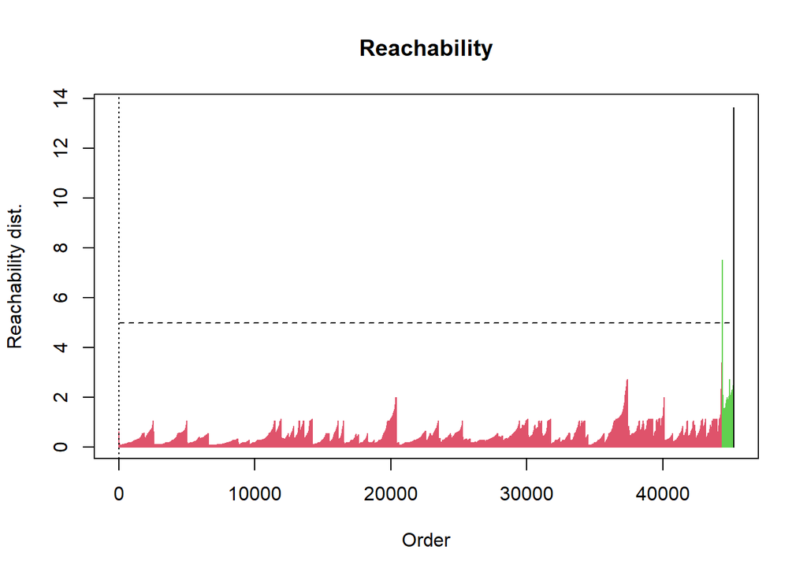

```r
library(dbscan)
library(dplyr)

optics_result_min50 <- dbscan::optics(scaled_data, minPts = 50)


dbscan_result_min50 <- extractDBSCAN(optics_result_min50, eps_cl = 5)
data$cluster_dbscan_min50 <- as.factor(dbscan_result_min50$cluster)

plot(dbscan_result, main="Reachability")
```

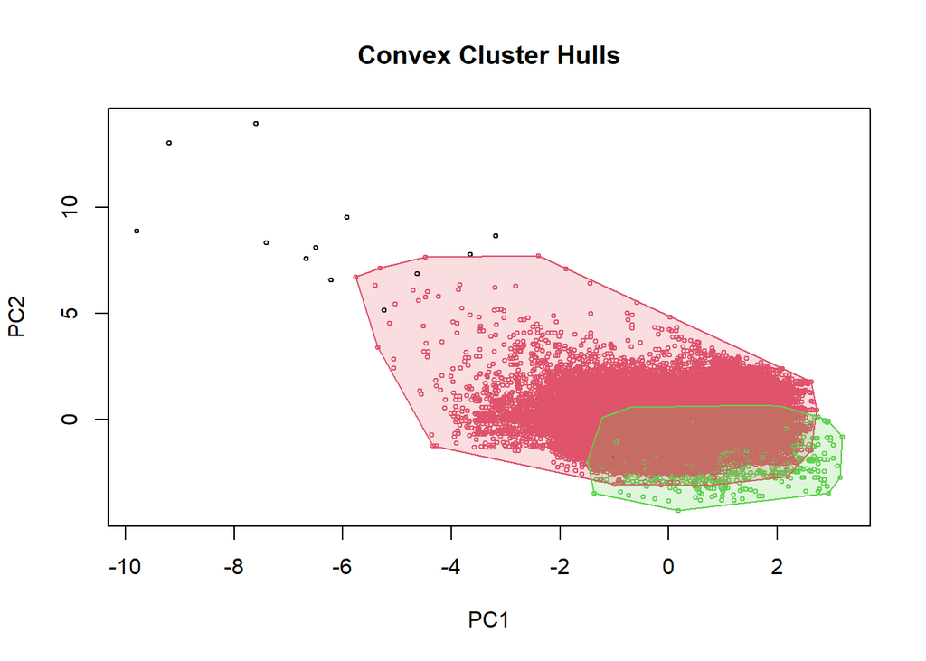

```r
hullplot(scaled_data, dbscan_result_min50)
```

```r
cluster_summary_dbscan_min50 <- data %>%
  group_by(cluster_dbscan_min50) %>%
  summarise(size = n(),
            avg_age = round(mean(age), 2),
            avg_balance = round(mean(balance), 2),
            most_common_job = names(sort(table(job), decreasing = TRUE))[1],
            job_frequency_percent = round(max(table(job)) / sum(table(job)) * 100, 2),
            positive_outcome_percent = round(sum(y == "yes") / n() * 100, 2)
  )
cluster_summary_dbscan_min50 <- bind_rows(overall_summary,cluster_summary_dbscan_min50)

print(cluster_summary_dbscan_min50)
```

```
##    size avg_age avg_balance most_common_job job_frequency_percent
## 1 45211   40.94     1362.27     blue-collar                 21.53
## 2    14   55.29    67123.86          admin.                 21.43
## 3 44383   40.96     1369.41     blue-collar                 21.47
## 4   814   39.53     -158.05     blue-collar                 24.69
##   positive_outcome_percent cluster_dbscan_min50
## 1                    11.70                 <NA>
## 2                    14.29                    0
## 3                    11.80                    1
## 4                     6.39                    2
```

We can see that the result is not appreciably different from minPts = 100.

DBSCAN is useful as a cluster identifier, but it requires more interaction to fine-tune for optimal results.

# 4 Supervised models

## 4.1 c5.0 tree

We will start by creating a decision tree based solely on customer information. We will select 80% of our 45,211 data points for training, leaving us with a split of 36,168 data points for training and 9,043 for testing.

```r
set.seed(123)
split_prop <- 0.8
dataTree <- na.omit(data[, c(1:8)])
indexes = sample(1:nrow(dataTree), size=floor(split_prop*nrow(dataTree)))


trainData<-dataTree[indexes,]
trainDataRes <- as.factor(data[indexes, (names(data) %in% c("y"))])
testData<-dataTree[-indexes,]

print(paste("Training rows:", nrow(trainData)))
```

```
## [1] "Training rows: 36168"
```

```r
print(paste("Test rows:", nrow(testData)))
```

```
## [1] "Test rows: 9043"
```

An 80/20 split is used at the upper limits of the standard, due to the limited size of the sample data.

We will generate the tree based on the personal data of the clients.

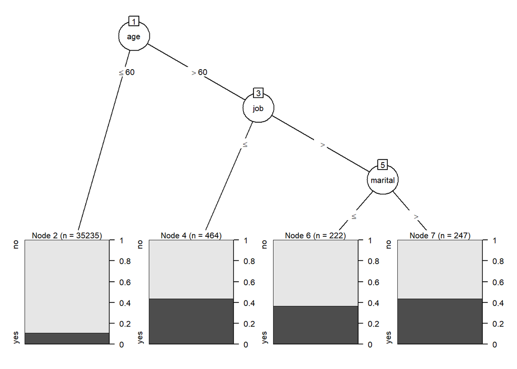

```r
set.seed(123)
library(grid)
library(C50)

model <- C5.0(trainData, trainDataRes)
plot(model,gp = gpar(fontsize = 8))
```

```r
model <- C5.0(trainData,trainDataRes, rules=TRUE)
summary(model)
```

```
##
## Call:
## C5.0.default(x = trainData, y = trainDataRes, rules = TRUE)
##
##
## C5.0 [Release 2.07 GPL Edition]      Mon Jan 29 19:59:27 2024
## -------------------------------
##
## Class specified by attribute `outcome'
##
## Read 36168 cases (9 attributes) from undefined.data
##
## Rules:
##
## Rule 1: (35235/3848, lift 1.0)
##  age <= 60
##  ->  class no  [0.891]
##
## Rule 2: (156/75, lift 4.4)
##  age > 60
##  job in {entrepreneur, management, admin., technician, blue-collar,
##                 retired, self-employed, unemployed, housemaid}
##  marital = divorced
##  ->  class yes  [0.519]
##
## Default class: no
##
##
## Evaluation on training data (36168 cases):
##
##          Rules
##    ----------------
##      No      Errors
##
##       2 4233(11.7%)   <<
##
##
##     (a)   (b)    <-classified as
##    ----  ----
##   31854    75    (a): class no
##    4158    81    (b): class yes
##
##
##  Attribute usage:
##
##   97.85% age
##    0.43% job
##    0.43% marital
##
##
## Time: 0.1 secs
```

We have generated a rather peculiar model, consisting of only 2 rules.

From the training data, it appears that only a subset of individuals with a notable difference in subscription ratio is found, in this case, people over 60 years old, especially those who are retired and/or divorced.

This indicates that the model, even without checking the confusion matrix, is unable to classify the majority of cases. However, it is worth mentioning the potential utility of identifying specific outliers.

We will generate the confusion matrix for the model to better understand its effectiveness.

```r
predictions <- predict(model, newdata = testData)

conf_matrix <- table(Actual = as.factor(data[-indexes, "y"]), Predicted = predictions)
print(conf_matrix)
```

```
##       Predicted
## Actual   no  yes
##    no  7968   25
##    yes 1034   16
```

```r
accuracy <- sum(diag(conf_matrix)) / sum(conf_matrix)
precision <- conf_matrix[2, 2] / sum(conf_matrix[, 2])
recall <- conf_matrix[2, 2] / sum(conf_matrix[2, ])
specificity <- conf_matrix[1, 1] / sum(conf_matrix[1, ])
error_rate <- 1 - accuracy

cat("\nAccuracy:", round(accuracy * 100, 2), "%\n")
```

```
##
## Accuracy: 88.29 %
```

```r
cat("Precision:", round(precision * 100, 2), "%\n")
```

```
## Precision: 39.02 %
```

```r
cat("Recall:", round(recall * 100, 2), "%\n")
```

```
## Recall: 1.52 %
```

```r
cat("Especifity:", round(specificity * 100, 2), "%\n")
```

```
## Especifity: 99.69 %
```

```r
cat("Error rate:", round(error_rate * 100, 2), "%\n")
```

```
## Error rate: 11.71 %
```

As expected, we see that the model, by classifying only a small subset as class 1 (subscribed), is extremely poor (1.5%) at correctly identifying positive cases. However, it’s worth noting its apparent excellent (99.7%) identification of negative cases.

We cannot observe notable differences, even with a high number of trials, indicating that the model is not suitable for identifying outliers in the outcome.

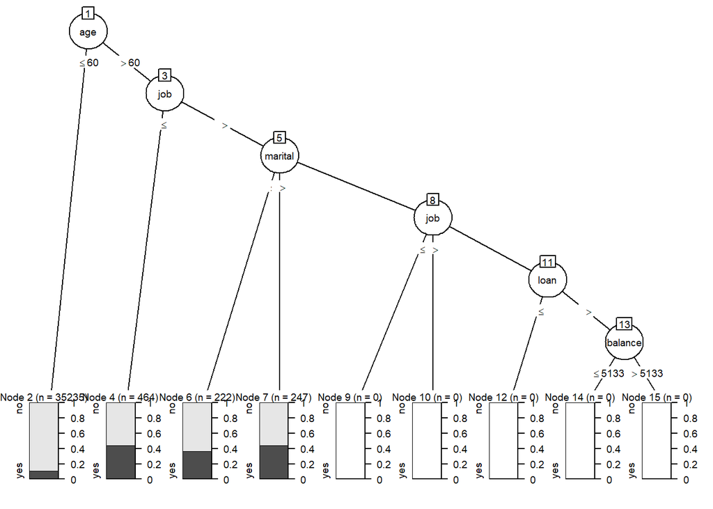

```r
set.seed(123)
library(grid)
library(C50)

model <- C5.0(trainData, trainDataRes, control = C5.0Control(minCases = 1), trials = 100)
plot(model,gp = gpar(fontsize = 7))
```

```r
model <- C5.0(trainData,trainDataRes, control = C5.0Control(minCases = 1), rules=TRUE)
summary(model)
```

```
##
## Call:
## C5.0.default(x = trainData, y = trainDataRes, rules = TRUE, control
##  = C5.0Control(minCases = 1))
##
##
## C5.0 [Release 2.07 GPL Edition]      Mon Jan 29 19:59:30 2024
## -------------------------------
##
## Class specified by attribute `outcome'
##
## Read 36168 cases (9 attributes) from undefined.data
##
## Rules:
##
## Rule 1: (21794/2206, lift 1.0)
##  marital = married
##  ->  class no  [0.899]
##
## Rule 2: (35235/3848, lift 1.0)
##  age <= 60
##  ->  class no  [0.891]
##
## Rule 3: (156/75, lift 4.4)
##  age > 60
##  job in {entrepreneur, management, admin., technician, blue-collar,
##                 retired, self-employed, unemployed, housemaid}
##  marital = divorced
##  ->  class yes  [0.519]
##
## Default class: no
##
##
## Evaluation on training data (36168 cases):
##
##          Rules
##    ----------------
##      No      Errors
##
##       3 4233(11.7%)   <<
##
##
##     (a)   (b)    <-classified as
##    ----  ----
##   31854    75    (a): class no
##    4158    81    (b): class yes
##
##
##  Attribute usage:
##
##   97.85% age
##   60.69% marital
##    0.43% job
##
##
## Time: 0.1 secs
```

However, there is a set of rules that do seem to be identified, corresponding to previous results from other models, indicating a profile of outliers corresponding to older retired individuals.

We can see that the generated models have a very low error rate (~11%); however, interpreting this as being due to the low original ratio of the outcome and the fact that the vast majority of cases fall into the negative outcome according to the rules, indicates the extremely poor sensitivity (~1%) of the model.

As observed in previous models, the use of personal data does not seem particularly conclusive in creating profiles to identify outliers in the outcome, except for certain specific profiles. The results of these rules seem to corroborate that based on the available data, it is not possible to classify the majority of the population.

## 4.2 randomForest

```r
library(randomForest)
library(iml)

dataForest <- cbind(trainData, y = trainDataRes)

rf <-  randomForest(y ~ ., data = dataForest, ntree = 50)
```

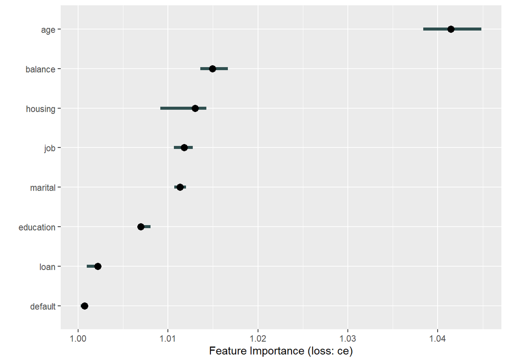

```r
X <- dataForest[which(names(dataForest) != "y")]
predictor <- Predictor$new(rf, data = X, y = dataForest$y)
imp <- FeatureImp$new(predictor, loss = "ce")
plot(imp)
```

We will check the effectiveness of the model generated with RandomForest by creating a confusion matrix using the dataset not used for its creation.

```r
predictions <- predict(rf, newdata = testData)

conf_matrix <- table(Actual = as.factor(data[-indexes, "y"]), Predicted = predictions)
print(conf_matrix)
```

```
##       Predicted
## Actual   no  yes
##    no  7989    4
##    yes 1045    5
```

We will generate metrics from the confusion matrix to compare the quality of the model.

```r
accuracy <- sum(diag(conf_matrix)) / sum(conf_matrix)
precision <- conf_matrix[2, 2] / sum(conf_matrix[, 2])
recall <- conf_matrix[2, 2] / sum(conf_matrix[2, ])
specificity <- conf_matrix[1, 1] / sum(conf_matrix[1, ])
error_rate <- 1 - accuracy

cat("\nAccuracy:", round(accuracy * 100, 2), "%\n")
```

```
##
## Accuracy: 88.4 %
```

```r
cat("Precision:", round(precision * 100, 2), "%\n")
```

```
## Precision: 55.56 %
```

```r
cat("Recall:", round(recall * 100, 2), "%\n")
```

```
## Recall: 0.48 %
```

```r
cat("Especifity:", round(specificity * 100, 2), "%\n")
```

```
## Especifity: 99.95 %
```

```r
cat("Error rate:", round(error_rate * 100, 2), "%\n")
```

```
## Error rate: 11.6 %
```

## 4.3 Conclusions

It has been observed that personal level data does not seem to be sufficient for creating general profiles for potential future clients, although some very specific profiles (such as older retired individuals and young people with capital) seem to have potential as future targets. Therefore, in a future study on the data, it would be of interest to observe the impact of variables on the contact itself to identify profiles.

The use of predictive models in advertising entails certain risks that must be carefully considered. One of the main risks lies in the extrapolation of the results obtained. While the model may identify “outlier” profiles with a potential ratio of positive outcomes, it is essential to recognize that these results are based on limited historical data. Extrapolating these findings to future campaigns may not be as effective if market conditions or underlying variables experience significant changes.

Although the model results seem to corroborate previous knowledge, in this case that the targets for a bank campaign should be those customers with disposable income and “naive” individuals, this could be due to the limited size of these populations and their nature as “extreme” cases. Therefore, an approach for a future campaign may not yield the expected results.

The clear result of the models is the interest in identifying “outlier” profiles due to their potential ratio of positive outcomes.

It is worth mentioning regarding the data the nature of the campaign and its effect on the data itself. An advertising campaign, especially direct telephone marketing, has a variety of variables not available in the data that can affect the outcome, from impossible-to-record information such as the client’s mood or past negative experiences, to the tone of voice of the operator or the temperature of the day. Therefore, the inability of a model of this category to entirely determine the causes for the outcome of the campaign must be taken into account, requiring these data to be analyzed and studied by operators and/or managers with deeper knowledge of the specific market.

In general terms, the use of predictive models for decision-making in advertising poses inherent risks. The accuracy of the models is directly related to the quality of the data and the ability to adapt to changes in market conditions. Additionally, there is a risk that the model results may be misinterpreted or overvalued, leading to erroneous strategic decisions. It is essential to implement risk mitigation measures, such as continuous validation of the model with updated data and active involvement of field experts to ensure informed and prudent decision-making.